# PeerAssessment1

R Mofidi

10/06/2020

## Introduction

It is now possible to collect a large amount of data about personal movement using activity monitoring devices such as a Fitbit, Nike Fuelband, or Jawbone Up. These type of devices are part of the “quantified self” movement – a group of enthusiasts who take measurements about themselves regularly to improve their health, to find patterns in their behavior, or because they are tech geeks. But these data remain under-utilized both because the raw data are hard to obtain and there is a lack of statistical methods and software for processing and interpreting the data.

This assignment makes use of data from a personal activity monitoring device. This device collects data at 5 minute intervals through out the day. The data consists of two months of data from an anonymous individual collected during the months of October and November, 2012 and include the number of steps taken in 5 minute intervals each day. This task has been divided into a number of headings listed below for which there is a segment of R Code enclosed. Each task leading to a histogram or plot will have that plot/histogram after the segment of R Code

## Loading and preprocessing the data

The data for this assignment can be downloaded from the course web site:

Dataset: Activity monitoring data [52K] The variables included in this dataset are:

*steps:* Number of steps taking in a 5-minute interval (missing values are coded as NA) date: The date on which the measurement was taken in YYYY-MM-DD format *interval:* Identifier for the 5-minute interval in which measurement was taken.

The dataset is stored in a comma-separated-value (CSV) file and there are a total of 17,568 observations in this dataset. The following piece of R code is used to download the data and perform the initial preprocessing steps. This involves loading the appropriate libraries, downloading the database and unziping files.

```r
library(dplyr)
```

```r
library(ggplot2)

## Download the database and unzip the files
if(!file.exists("~/data")){dir.create("~/data")}
fileUrl <- "https://d396qusza40orc.cloudfront.net/repdata%2Fdata%2Factivity.zip"
download.file(fileUrl,destfile="~/data/repdata_data_activity.zip")
setwd("~/data")
unzip("~/data/repdata_data_activity.zip", exdir="~/data")
activity<- read.csv("activity.csv", header=TRUE, sep=",")

activity$day<- weekdays(as.Date(activity$date))
activityDT<- as.POSIXct(activity$date, format="%Y-%m-%d")

Tablesteps<- aggregate(activity$steps ~ activity$date, FUN=sum, )
colnames(Tablesteps)<- c("date", "steps")
```

## What is mean total number of steps taken per day?

The tsk here is to calculate the total number of steps taken per day from which we are instructed to make a histogram of the total number of steps taken each day

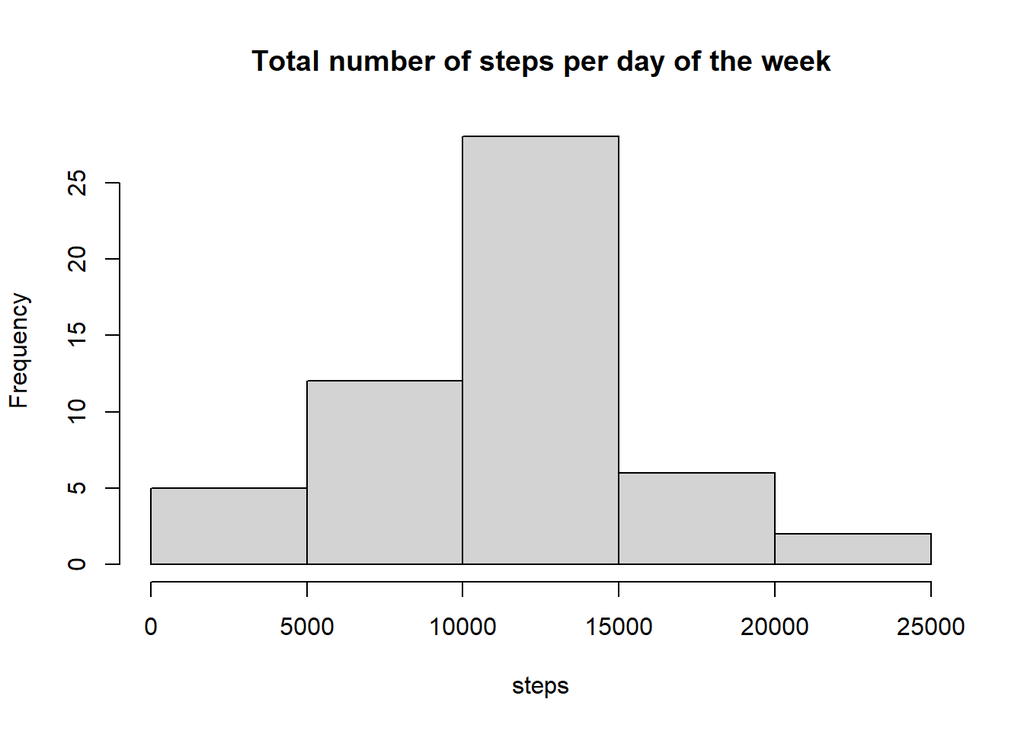

```r
activity$day<- weekdays(as.Date(activity$date))
activityDT<- as.POSIXct(activity$date, format="%Y-%m-%d")

Tablesteps<- aggregate(activity$steps ~ activity$date, FUN=sum, )
colnames(Tablesteps)<- c("date", "steps")
hist(Tablesteps$steps, breaks=5, xlab = "steps", main = "Total number of steps per day of the week")
```

This is a histogram of total number of steps taken per day

[figure not shown]

The following values are the mean and median number of steps per day

```
## [1] 10766.19
```

```
## [1] 10765
```